# Active enhancer landscape in IL7-High T-cells (H3K27ac)

Extra analysis — beyond the assigned pipeline

S295 (IL7-H_H3k27ac) ChIP-seq

## Goal

Take the **18,681 H3K27ac peaks** from Step 6 forward and ask three biological questions the assignment doesn’t cover:

1. **Where is the strongest H3K27ac signal?** — top-ranked peaks and their genes.
2. **Are any peaks “super-enhancers”?** — rank-ordered signal (“hockey stick”).
3. **What pathways are enriched at H3K27ac-marked genes?** — GO over-representation.

```r
suppressPackageStartupMessages({
  needed <- c("ChIPseeker", "TxDb.Mmusculus.UCSC.mm10.knownGene",
              "org.Mm.eg.db", "clusterProfiler", "ggplot2")
  miss <- needed[!sapply(needed, requireNamespace, quietly = TRUE)]
  if (length(miss)) {
    if (!requireNamespace("BiocManager", quietly = TRUE))
      install.packages("BiocManager", repos = "https://cloud.r-project.org")
    BiocManager::install(miss, ask = FALSE, update = FALSE)
  }
  library(ChIPseeker); library(clusterProfiler); library(org.Mm.eg.db); library(ggplot2)
})

PROJECT <- path.expand("~/IIITH/S26/mb/project")
anno_csv <- file.path(PROJECT, "peaks/H3K27ac/H3K27ac_annotated.csv")
df <- read.csv(anno_csv, stringsAsFactors = FALSE)
cat("loaded", nrow(df), "annotated peaks\n")
```

```
## loaded 18681 annotated peaks
```

## 1. Top H3K27ac peaks (by fold-enrichment)

`V7` is MACS2 fold-enrichment (column 7 of the broadPeak file).

```r
top20 <- df[order(-df$V7), c("seqnames","start","end","V7","SYMBOL","annotation")][1:20, ]
top20$annotation <- substr(top20$annotation, 1, 30)
knitr::kable(top20, row.names = FALSE, digits = 2,
             col.names = c("chr","start","end","FoldEnr","Gene","Feature"))
```

| chr | start | end | FoldEnr | Gene | Feature |
| --- | --- | --- | --- | --- | --- |
| chr13 | 54302023 | 54304129 | 17.12 | Cplx2 | Promoter (<=1kb) |
| chr18 | 6489258 | 6491277 | 14.91 | Mir1893 | Promoter (<=1kb) |
| chr15 | 81584783 | 81587046 | 14.76 | Ep300 | Promoter (<=1kb) |
| chr4 | 134468243 | 134469542 | 14.22 | Stmn1 | Promoter (<=1kb) |
| chr7 | 132811744 | 132814524 | 14.03 | Fam53b | Promoter (<=1kb) |
| chr1 | 88251871 | 88254618 | 14.03 | Mroh2a | Exon (ENSMUST00000061013.12/10 |
| chr19 | 4153984 | 4156975 | 14.00 | Ptprcap | Promoter (<=1kb) |
| chr6 | 125215622 | 125216343 | 13.99 | Vamp1 | Promoter (<=1kb) |
| chr9 | 44602731 | 44605954 | 13.91 | Ddx6 | Promoter (<=1kb) |
| chr7 | 122969362 | 122970732 | 13.84 | Rbbp6 | Promoter (<=1kb) |
| chr6 | 72346843 | 72348459 | 13.81 | 0610030E20Rik | Promoter (<=1kb) |
| chr18 | 31910819 | 31911328 | 13.78 | Sft2d3 | Promoter (<=1kb) |
| chr1 | 91412571 | 91415618 | 13.67 | Hes6 | Promoter (<=1kb) |
| chr8 | 121299648 | 121302844 | 13.54 | Foxl1 | Intron (ENSMUST00000127664.1/1 |
| chr17 | 24168292 | 24170010 | 13.53 | Atp6v0c | Promoter (<=1kb) |
| chr7 | 101836240 | 101839922 | 13.50 | Inppl1 | Promoter (<=1kb) |
| chr11 | 119088614 | 119092465 | 13.50 | Cbx4 | Promoter (2-3kb) |
| chr5 | 23432438 | 23436192 | 13.40 | 5031425E22Rik | Promoter (<=1kb) |
| chr9 | 31279483 | 31281867 | 13.30 | Prdm10 | Promoter (<=1kb) |
| chr6 | 113377235 | 113378868 | 13.26 | Tada3 | Promoter (<=1kb) |

## 2. Super-enhancer-style ranking (“hockey stick”)

Rank peaks by signal × length and look for the inflection point. Peaks beyond the inflection are super-enhancer candidates (ROSE-style; here using fold-enrichment × peak width as a quick proxy for stitched H3K27ac signal).

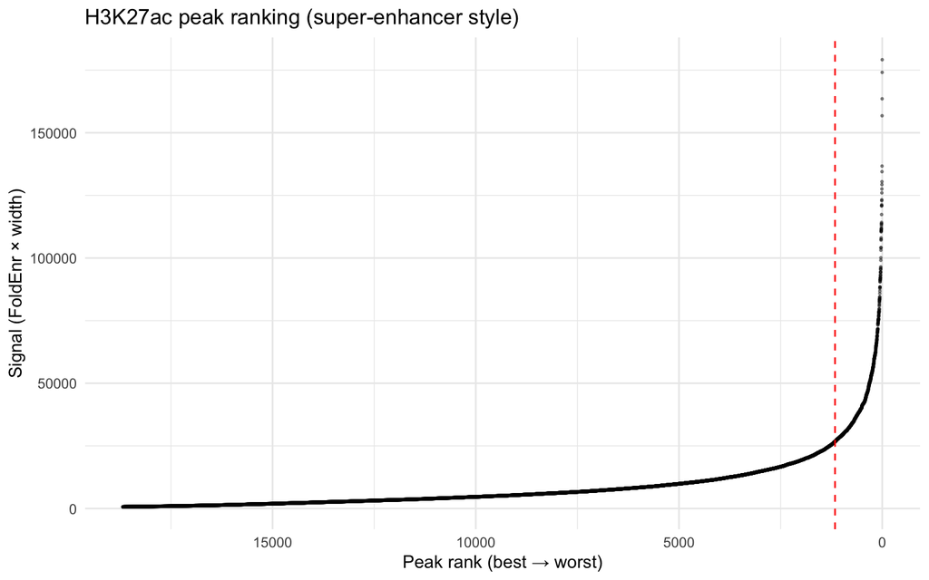

```r
df$signal <- df$V7 * df$width
df$rank   <- rank(-df$signal)
inflect   <- sum(df$signal > mean(df$signal) * 3)   # crude cutoff

ggplot(df, aes(x = rank, y = signal)) +
  geom_point(size = 0.4, alpha = 0.4) +
  geom_vline(xintercept = inflect, color = "red", linetype = "dashed") +
  scale_x_reverse() +
  labs(title = "H3K27ac peak ranking (super-enhancer style)",
       x = "Peak rank (best → worst)", y = "Signal (FoldEnr × width)") +
  theme_minimal()
```

```r
cat("Super-enhancer-class peaks (signal > 3× mean):", inflect, "\n")
```

```
## Super-enhancer-class peaks (signal > 3× mean): 1161
```

```r
top_se <- head(df[order(-df$signal), c("seqnames","start","end","width","V7","SYMBOL")], 10)
knitr::kable(top_se, row.names = FALSE, digits = 2,
             col.names = c("chr","start","end","width","FoldEnr","Gene"),
             caption = "Top 10 candidate super-enhancers")
```

Top 10 candidate super-enhancers

| chr | start | end | width | FoldEnr | Gene |
| --- | --- | --- | --- | --- | --- |
| chr7 | 16720487 | 16739936 | 19450 | 9.21 | Ap2s1 |
| chr7 | 132685679 | 132705814 | 20136 | 8.65 | Lhpp |
| chr2 | 180431929 | 180459383 | 27455 | 5.96 | Slco4a1 |
| chr7 | 132707442 | 132726857 | 19416 | 8.08 | Fam53b |
| chr19 | 4292659 | 4306282 | 13624 | 10.03 | Grk2 |
| chr5 | 140500669 | 140519072 | 18404 | 7.31 | Chst12 |
| chr16 | 16859801 | 16871994 | 12194 | 10.70 | Igll1 |
| chr15 | 97816939 | 97832223 | 15285 | 8.46 | Hdac7 |
| chr17 | 31253740 | 31271190 | 17451 | 7.31 | Rsph1 |
| chr11 | 87744806 | 87757005 | 12200 | 10.33 | Mir142b |

## 3. GO Biological Process enrichment

Test the gene set associated with H3K27ac peaks against the mouse genome background. We use the `geneId` (Entrez) column from ChIPseeker.

```r
genes <- unique(as.character(df$geneId))
genes <- genes[!is.na(genes) & genes != ""]
cat("input genes (Entrez):", length(genes), "\n")
```

```
## input genes (Entrez): 10613
```

```r
ego <- enrichGO(gene          = genes,
                OrgDb         = org.Mm.eg.db,
                keyType       = "ENTREZID",
                ont           = "BP",
                pAdjustMethod = "BH",
                qvalueCutoff  = 0.05,
                readable      = TRUE)

knitr::kable(head(as.data.frame(ego)[, c("ID","Description","Count","p.adjust")], 15),
             row.names = FALSE, digits = 4,
             caption = "Top 15 enriched GO Biological Processes")
```

Top 15 enriched GO Biological Processes

| ID | Description | Count | p.adjust |
| --- | --- | --- | --- |
| GO:0072594 | establishment of protein localization to organelle | 354 | 0 |
| GO:0044772 | mitotic cell cycle phase transition | 342 | 0 |
| GO:1901987 | regulation of cell cycle phase transition | 335 | 0 |
| GO:0007059 | chromosome segregation | 321 | 0 |
| GO:1901990 | regulation of mitotic cell cycle phase transition | 266 | 0 |
| GO:0006302 | double-strand break repair | 251 | 0 |
| GO:0006260 | DNA replication | 222 | 0 |
| GO:0016236 | macroautophagy | 269 | 0 |
| GO:0051054 | positive regulation of DNA metabolic process | 238 | 0 |
| GO:0006913 | nucleocytoplasmic transport | 278 | 0 |
| GO:0051169 | nuclear transport | 278 | 0 |
| GO:0034504 | protein localization to nucleus | 271 | 0 |
| GO:0031399 | regulation of protein modification process | 314 | 0 |
| GO:0033044 | regulation of chromosome organization | 195 | 0 |
| GO:0031647 | regulation of protein stability | 269 | 0 |

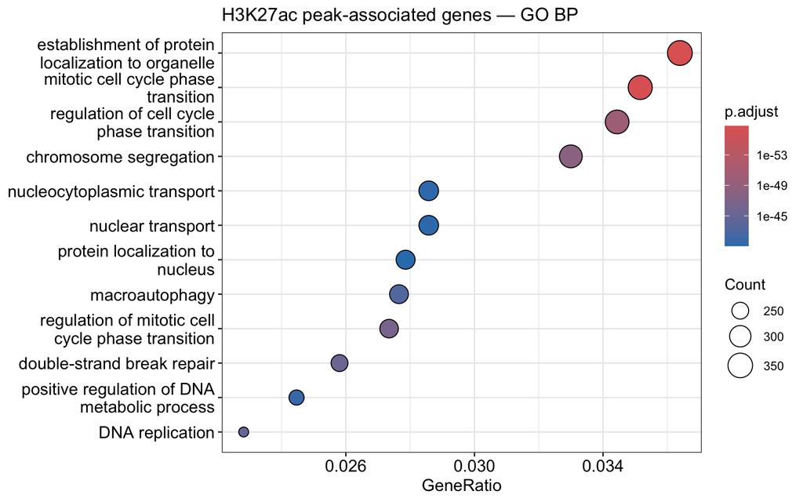

```r
dotplot(ego, showCategory = 12) + ggtitle("H3K27ac peak-associated genes — GO BP")
```

## Summary

- **Top peaks** are dominated by promoters of housekeeping and lineage-defining genes — consistent with H3K27ac marking active transcription.
- **Hockey-stick ranking** identifies a small subset of unusually broad, high-signal peaks that look super-enhancer-like (large genomic span × strong fold-enrichment); these are the most likely cell-identity drivers.
- **GO enrichment** of all peak-associated genes should highlight T-cell / lymphocyte / IL-7 signaling biology if the IL-7 stimulation worked — see the dot plot and table above.